# Data Analysis for O’Day and Karpicke (2020) E2

# 1 - Setting up R

```r
rm(list = ls())     # clears R history and console for a tidy workspace
options(scipen=999) # turns off scientific notation
```

## 1.1 - Packages

if you do not already have the package you will need to use install.packages(“packageName”)

```r
library(kableExtra)    # for pretty output
library(gridExtra)     # for plotting two plots next to each other
library(tidyverse)     # for data management
library(readxl)        # for reading excel files
library(MBESS)         # for effect size
library(MOTE)          # for apa function for limiting decimals
library(ez)            # for ANOVA
```

## 1.2 - Effect size function

This function returns Cohen’s D in a neat format for a t-test analysis.

This function requires:

- the type of analysis (between or within)
- the dataFrame, the dataFormat (long or wide)
- the name of the outcome and predictor variables or columns
- the sample size (between use n1 and n2; within use N).

```r
effSize <- function(analysis, dataFrame, dataFormat, outcome, predictor, n1, n2, N) {

  # get the column number for outcome and predictor variables
  outcomeColumn = which(colnames(dataFrame) == outcome)
  predictorColumn = which(colnames(dataFrame) == predictor)

  if (analysis == "between") {
    paired = F # do not do a paired t test for between subjects design
  } else {
    paired = T # do a paired t test for within subjects design
  }

  if (is.numeric(dataFrame[[predictorColumn]])) {
    t <- t.test(dataFrame[[outcomeColumn]],dataFrame[[predictorColumn]],
                paired = paired, var.equal = T)
  } else {
    t <- t.test(dataFrame[[outcomeColumn]]~dataFrame[[predictorColumn]],
                paired = paired, var.equal = T)
  }


  ncp <- t$statistic

  if (analysis == "between") {
    df = n1 + n2 - 2
    effectSize <- ci.smd(ncp=ncp, n.1=n1, n.2=n2)
    d          <- apa(effectSize$smd, 2)
    dlow       <- apa(effectSize$Lower.Conf.Limit.smd,2)
    dhigh      <- apa(effectSize$Upper.Conf.Limit.smd,2)
  } else {
    df = N - 1
    effectSize <- capture.output(ci.sm(ncp=ncp, N=N)) # prevents MBESS printing to output
    d          <- apa(as.numeric(substring(effectSize[7],0)),2)
    dlow       <- apa(as.numeric(substring(effectSize[3],5)),2)
    dhigh      <- apa(as.numeric(substring(effectSize[10],5)),2)
  }

  p <- apa(t$p.value,3)
  t <- apa(t$statistic,2)

  # create tidy output
  summary <- paste("t(",df,") = ", t, ", p = ",p, ",",
                   " d = ", d, " [", dlow, ", ", dhigh, "]", sep="")

  names  <- c("t","df","p","d","dlow","dhigh","summary")
  values <- c(t,df,p,d,dlow,dhigh,summary)

  output <- rbind(names,values)
  output <- data.frame(names,values)

  output <- output %>%
    spread(key=names,value=values) %>%
    select("t", "df", "p", "d","dlow", "dhigh","summary")

  return(output)
}
```

## 1.3 - Annotation function

This function accepts name of data frame that has a column with mean values. For each row in the dataTable, go through columName, get each cell value and create an annotation for that value, add that annotation to a list.

- annotations will be added to graph in order they appear in dataTable
- columnName needs to be entered as a string (e.g., “mean”)

```r
storage = list() # create storage container for use during looping
annotations <- function (dataTable, columnName) {
    columnNumber = which(colnames(dataTable) == columnName)
    for (i in 1:nrow(dataTable)) {
      name <- paste("A",i,sep="")
      annotation <- assign(name,annotate("text", x = i, y = 0.05, label = as.character(dataTable[i,columnNumber]), size = 9))
      storage[i] <- c(annotation)
    }
    return(storage)
}
```

## 1.4 - Plot theme

Custom theme that is added onto a ggplot object that makes nice looking plots

```r
PCLLABtheme <-
  theme(
    # titles
      plot.title   = element_text(size= 26, face = "bold",margin=margin(0,0,8,0), hjust = 0.5),
      axis.title.x = element_text(margin=margin(6,0,0,0)),
      axis.title.y = element_text(size = 24, face = "bold", margin=margin(0,10,0,0)),
    # axes
      axis.text.x = element_text(size = 23, colour="black", margin=margin(14,0,0,0,"pt")),
      axis.text.y = element_text(size = 24, colour="black", margin=margin(0,8,0,0,"pt")),
      axis.line   = element_line(colour = "black"),
    # panel
      panel.grid.major = element_blank(),
      panel.grid.minor = element_blank(),
      panel.background = element_rect(fill = "white"),
    # tick marks
      axis.ticks.length = unit(-.2, "cm"),
      axis.ticks.x      = element_blank(),
      axis.ticks.y      = element_line(colour="black"),
    # legend
      legend.position = "none" # removes legend
    )
```

## 1.5 - Read in data

Be sure to set your working directory to the appropriate place.

I find it easiest to click on “Session” => “Set working directory” => “To File Source Location”.

```r
# list all of the files and folders in the data folder within the working directory
  list.files("data")

# read in data - note this is an xlsx file with multiple sheets
  E2data <- read_excel("data/finalData.CMRP.E2.xlsx", sheet = 2)
```

# 2 - Demographics

```r
# age
  summary(E2data$age)
```

```
   Min. 1st Qu.  Median    Mean 3rd Qu.    Max.
  18.00   19.00   20.00   19.95   21.00   33.00
```

```r
  sd(E2data$age)
```

```
[1] 2.061451
```

```r
# age by condition
  E2data %>%
    group_by(condition) %>%
    summarize(meanAge = mean(age))
```

| condition | meanAge |
| --- | --- |
| CM | 19.66667 |
| CM+RP | 20.10000 |
| RP | 19.96667 |
| Study | 20.06667 |

```r
# ANOVA - age
  ezANOVA(
      E2data
      , age
      , subNum
      , between = condition
      , type = 3
      , detailed = T
    )
```

```
Converting "subNum" to factor for ANOVA.Converting "condition" to factor for ANOVA.Coefficient covariances computed by hccm()
```

|  | Effect | DFn | DFd | SSn | SSd | F | p | p<.05 | ges |
| --- | --- | --- | --- | --- | --- | --- | --- | --- | --- |
| 1 | (Intercept) | 1 | 116 | 47760.3 | 502.2 | 11031.849462 | 0.000000000000000000000000000000000000000000000000000000000000000000000000000000000000000000000000000000000000000000007455686 | * | 0.989594406 |
| 2 | condition | 3 | 116 | 3.5 | 502.2 | 0.269481 | 0.847289967820771261486356706882361322641372680664062500000000000000000000000000000000000000000000000000000000000000000000000 |  | 0.006921099 |

```
$`Levene's Test for Homogeneity of Variance`
```

| DFn | DFd | SSn | SSd | F | p | p<.05 |
| --- | --- | --- | --- | --- | --- | --- |
| 3 | 116 | 3.266667 | 320.4333 | 0.3941884 | 0.7574142 |  |

```r
# gender
  table(E2data$gender)
```

```
female   male
    51     69
```

```r
# gender by condition
  table(E2data$condition,E2data$gender)
```

```
        female male
  CM        15   15
  CM+RP     13   17
  RP         9   21
  Study     14   16
```

```r
  chisq.test(table(E2data$condition,E2data$gender))
```

```
    Pearson's Chi-squared test

data:  table(E2data$condition, E2data$gender)
X-squared = 2.8303, df = 3, p-value = 0.4185
```

# 3 - Concept map performance

```r
# make condition CM+RP come first so that t value is positive
  E2data$condition <- factor(E2data$condition, levels = c("CM+RP", "CM","Study","RP"))
# descriptives
  kable(E2data %>%
          filter(condition == "CM+RP" | condition == "CM") %>%
          group_by(condition) %>%
          summarize(meanMapPerf = apa(mean(map_score, na.rm = T) / 27, 2),
                    sdMapPerf   = apa(sd  (map_score, na.rm = T) / 27, 2)), align = "c") %>%
          kable_styling(full_width = F, position = "left", font_size = 14)
```

| condition | meanMapPerf | sdMapPerf |
| --- | --- | --- |
| CM+RP | 0.75 | 0.13 |
| CM | 0.72 | 0.13 |

```r
# effect size function
  kable(effSize(data = E2data %>% filter(condition == "CM+RP" | condition == "CM") %>% droplevels()
    , analysis = "between"            # within or between
    , dataFormat = "wide"             # long or wide data
    , outcome = "map_score"           # the outcome variable
    , predictor = "condition"         # the predictor predictor variable
    , n1 = 30                         # sample size for group 1 for between-subjects designs
    , n2 = 30                         # sample size for group 2 for between-subjects designs
    ), caption = "Map performance - CM vs. CM+RP") %>%
    kable_styling("condensed", full_width = F, font_size = 14, position = "left")
```

Map performance - CM vs. CM+RP

| t | df | p | d | dlow | dhigh | summary |
| --- | --- | --- | --- | --- | --- | --- |
| 0.98 | 58 | 0.334 | 0.25 | -0.26 | 0.76 | t(58) = 0.98, p = 0.334, d = 0.25 [-0.26, 0.76] |

# 4 - Retrieval practice performance

A 2 (condition: retrieval practice vs. CM+RP) X 2 (recall test: 1 or 2) mixed factorial ANOVA was conducted

Retrieval practice performance was qualified by a significant recall number by condition interaction.

```r
# get data in correct format for ezANOVA
  E2recallData <- E2data %>%
    filter(condition == "RP" | condition == "CM+RP") %>% # filter out study and CM
    droplevels() %>% # remove the conditions that were filtered out
    select(subNum,condition,recall_1_score,recall_2_score) %>% # select relevant columns
    gather(key = recallNumber, value = recallScore, 3:4) %>% # convert wide data to long
    mutate(recallProportion = recallScore / 27) # convert score to proportion

# make subNum a factor for ezANOVA
  E2recallData$subNum <- as.factor(E2recallData$subNum)

# make recallNumber a factor for ezANOVA
  E2recallData$recallNumber <- as.factor(E2recallData$recallNumber)

# make cond a factor for ezANOVA
  E2recallData$condition <- as.factor(E2recallData$condition)

# ANOVA
  recallAnova <- ezANOVA(
    E2recallData
    , recallProportion
    , subNum
    , within = recallNumber
    , between = condition
    , type = 3
    , detailed = T
  )
# make output from ANOVA a tidy data frame
  anovaTable <- data.frame(recallAnova) %>%
    rename("predictor" = 1, "DFn" = 2, "DFd" = 3, "SSn" = 4,
           "SSd" = 5, "F" = 6, "p" = 7, "sig" = 8, "ges" = 9) %>% # rename columns
    mutate(pes = SSn / (SSn + SSd)) %>% # calculate partial eta squared
    mutate_if(is.numeric, round, digits = 3) # limit decimals to 3
```

```r
# create a nice table
  kable(anovaTable, align = "c", booktabs = T) %>%
      kable_styling("condensed", full_width = F, font_size = 14, position = "left")
```

| predictor | DFn | DFd | SSn | SSd | F | p | sig | ges | pes |
| --- | --- | --- | --- | --- | --- | --- | --- | --- | --- |
| (Intercept) | 1 | 58 | 52.939 | 3.443 | 891.670 | 0.000 | * | 0.931 | 0.939 |
| condition | 1 | 58 | 0.001 | 3.443 | 0.009 | 0.923 |  | 0.000 | 0.000 |
| recallNumber | 1 | 58 | 0.761 | 0.497 | 88.864 | 0.000 | * | 0.162 | 0.605 |
| condition:recallNumber | 1 | 58 | 0.117 | 0.497 | 13.619 | 0.000 | * | 0.029 | 0.190 |

## 4.1 - Recall 1

```r
# filter out recall 2
  E2R1data <- E2recallData %>%
    filter(recallNumber == "recall_1_score")

# descriptives
  kable(E2R1data %>%
    group_by(condition) %>%
    summarize(meanR1 = apa(mean(recallProportion),2), sdR1 = apa(sd(recallProportion),2))) %>%
    kable_styling("condensed", full_width = F, font_size = 14, position = "left")
```

| condition | meanR1 | sdR1 |
| --- | --- | --- |
| CM+RP | 0.61 | 0.17 |
| RP | 0.56 | 0.21 |

```r
# effect size function
  kable(effSize(data = E2R1data
    , analysis = "between"            # within or between
    , dataFormat = "long"             # long or wide data
    , outcome = "recallProportion"    # the outcome variable
    , predictor = "condition"         # the predictor predictor variable
    , n1 = 30                         # sample size for group 1 for between-subjects designs
    , n2 = 30                         # sample size for group 2 for between-subjects designs
    ), caption = "Recall 1 - CM+RP vs. RP") %>%
    kable_styling("condensed", full_width = F, font_size = 14, position = "left")
```

Recall 1 - CM+RP vs. RP

| t | df | p | d | dlow | dhigh | summary |
| --- | --- | --- | --- | --- | --- | --- |
| 1.17 | 58 | 0.246 | 0.30 | -0.21 | 0.81 | t(58) = 1.17, p = 0.246, d = 0.30 [-0.21, 0.81] |

## 4.2 - Recall 2

```r
# filter out recall 2
  E2R2data <- E2recallData %>%
    filter(recallNumber == "recall_2_score")

# make condition CM+RP first
  E2R2data$condition <- factor(E2R2data$condition, levels = c("CM+RP", "RP"))

# descriptives
  kable(E2R2data %>%
    group_by(condition) %>%
    summarize(meanR1 = apa(mean(recallProportion),2), sdR1 = apa(sd(recallProportion),2))) %>%
    kable_styling("condensed", full_width = F, font_size = 14, position = "left")
```

| condition | meanR1 | sdR1 |
| --- | --- | --- |
| CM+RP | 0.71 | 0.17 |
| RP | 0.78 | 0.19 |

```r
# effect size function
  kable(effSize(data = E2R2data
    , analysis = "between"            # within or between
    , dataFormat = "long"             # long or wide data
    , outcome = "recallProportion"    # the outcome variable
    , predictor = "condition"         # the predictor predictor variable
    , n1 = 30                         # sample size for group 1 for between-subjects designs
    , n2 = 30                         # sample size for group 2 for between-subjects designs
    ), caption = "Recall 2 - RP vs. CM+RP") %>%
    kable_styling("condensed", full_width = F, font_size = 14, position = "left")
```

Recall 2 - RP vs. CM+RP

| t | df | p | d | dlow | dhigh | summary |
| --- | --- | --- | --- | --- | --- | --- |
| -1.46 | 58 | 0.149 | -0.38 | -0.89 | 0.13 | t(58) = -1.46, p = 0.149, d = -0.38 [-0.89, 0.13] |

# 5 - Judgments of Learning

```r
# ANOVA
  E2data$subNum    <- as.factor(E2data$subNum)    # convert to factor for ANOVA
  E2data$condition <- as.factor(E2data$condition) # convert to factor for ANOVA
  jolAnova <- ezANOVA(
    E2data
    , JOL
    , subNum
    , between = condition
    , type = 3
    , detailed = T
  )
```

Coefficient covariances computed by hccm()

```r
# make output from ANOVA a tidy data frame
  jolAnovaTable <- data.frame(jolAnova) %>%
    select(1:9) %>%
    rename("predictor" = 1, "DFn" = 2, "DFd" = 3, "SSn" = 4,
           "SSd" = 5, "F" = 6, "p" = 7, "sig" = 8, "ges" = 9) %>% # rename columns
    mutate(pes = SSn / (SSn + SSd)) %>% # calculate partial eta squared
    mutate_if(is.numeric, round, digits = 3) # limit decimals to 3
```

```r
# descriptives
  kable(E2data %>%
    group_by(condition) %>%
    summarize(meanJOL = apa(mean(JOL),2), sdJOL2 = apa(sd(JOL),2))) %>%
    kable_styling(bootstrap_options = "condensed", full_width = F, position = "left", font_size = 14)
```

| condition | meanJOL | sdJOL2 |
| --- | --- | --- |
| CM+RP | 0.64 | 0.18 |
| CM | 0.71 | 0.23 |
| Study | 0.67 | 0.24 |
| RP | 0.61 | 0.23 |

```r
# create a nice table
  kable(jolAnovaTable, align = "c", booktabs = T) %>%
    kable_styling("condensed", full_width = F, font_size = 14, position = "left")
```

| predictor | DFn | DFd | SSn | SSd | F | p | sig | ges | pes |
| --- | --- | --- | --- | --- | --- | --- | --- | --- | --- |
| (Intercept) | 1 | 116 | 51.614 | 5.63 | 1063.389 | 0.000 | * | 0.902 | 0.902 |
| condition | 3 | 116 | 0.166 | 5.63 | 1.137 | 0.337 |  | 0.029 | 0.029 |

There were no significant differences in the JOLs.

# 6 - Test performance

## 6.1 - Verbatim questions

```r
# convert score to proportion
  E2data$verbProportion <- E2data$SA_verbatim / 10

# change order of conditions so t values are positive
  E2data$condition <- factor(E2data$condition, levels = c("CM+RP", "RP", "CM", "Study"))

# descriptives
  kable(E2data %>%
    group_by(condition) %>%
    summarize(meanVerbProportion = apa(mean(verbProportion),2),
              sdVerbProportion = apa(sd(verbProportion),2))) %>%
    kable_styling("condensed", full_width = F, font_size = 14, position = "left")
```

| condition | meanVerbProportion | sdVerbProportion |
| --- | --- | --- |
| CM+RP | 0.78 | 0.14 |
| RP | 0.83 | 0.14 |
| CM | 0.55 | 0.22 |
| Study | 0.41 | 0.26 |

```r
# RP vs. Study Only
  kable(effSize(data = E2data %>% filter(condition == "RP"| condition == "Study") %>% droplevels()
    , analysis = "between"            # within or between design
    , dataFormat = "long"             # long or wide data
    , outcome = "verbProportion"      # the outcome variable
    , predictor = "condition"         # the predictor predictor variable
    , n1 = 30                         # sample size for between-group designs
    , n2 = 30                         # sample size for between-group designs
    ), caption = "Verbatim - RP vs. Study") %>%
    kable_styling("condensed", full_width = F, font_size = 14, position = "left")
```

Verbatim - RP vs. Study

| t | df | p | d | dlow | dhigh | summary |
| --- | --- | --- | --- | --- | --- | --- |
| 7.93 | 58 | 0.000 | 2.05 | 1.41 | 2.67 | t(58) = 7.93, p = 0.000, d = 2.05 [1.41, 2.67] |

```r
# CM+RP vs Study Only
  kable(effSize(data = E2data %>% filter(condition == "CM+RP"| condition == "Study") %>% droplevels()
    , analysis = "between"            # within or between design
    , dataFormat = "long"             # long or wide data
    , outcome = "verbProportion"      # the outcome variable
    , predictor = "condition"         # the predictor predictor variable
    , n1 = 30                         # sample size for between-group designs
    , n2 = 30                         # sample size for between-group designs
    ), caption = "Verbatim - CM+RP vs. Study") %>%
    kable_styling("condensed", full_width = F, font_size = 14, position = "left")
```

Verbatim - CM+RP vs. Study

| t | df | p | d | dlow | dhigh | summary |
| --- | --- | --- | --- | --- | --- | --- |
| 6.95 | 58 | 0.000 | 1.79 | 1.19 | 2.39 | t(58) = 6.95, p = 0.000, d = 1.79 [1.19, 2.39] |

```r
# CM vs Study Only
  kable(effSize(data = E2data %>% filter(condition == "CM"| condition == "Study") %>% droplevels()
    , analysis = "between"            # within or between design
    , dataFormat = "long"             # long or wide data
    , outcome = "verbProportion"      # the outcome variable
    , predictor = "condition"         # the predictor predictor variable
    , n1 = 30                         # sample size for between-group designs
    , n2 = 30                         # sample size for between-group designs
    ), caption = "Verbatim - CM vs. Study") %>%
    kable_styling("condensed", full_width = F, font_size = 14, position = "left")
```

Verbatim - CM vs. Study

| t | df | p | d | dlow | dhigh | summary |
| --- | --- | --- | --- | --- | --- | --- |
| 2.27 | 58 | 0.027 | 0.59 | 0.07 | 1.10 | t(58) = 2.27, p = 0.027, d = 0.59 [0.07, 1.10] |

```r
# RP vs CM
  kable(effSize(data = E2data %>% filter(condition == "RP"| condition == "CM") %>% droplevels()
    , analysis = "between"            # within or between design
    , dataFormat = "long"             # long or wide data
    , outcome = "verbProportion"      # the outcome variable
    , predictor = "condition"         # the predictor predictor variable
    , n1 = 30                         # sample size for between-group designs
    , n2 = 30                         # sample size for between-group designs
    ), caption = "Verbatim - RP vs. CM") %>%
    kable_styling("condensed", full_width = F, font_size = 14, position = "left")
```

Verbatim - RP vs. CM

| t | df | p | d | dlow | dhigh | summary |
| --- | --- | --- | --- | --- | --- | --- |
| 5.88 | 58 | 0.000 | 1.52 | 0.94 | 2.09 | t(58) = 5.88, p = 0.000, d = 1.52 [0.94, 2.09] |

```r
# CM+RP vs CM
  kable(effSize(data = E2data %>% filter(condition == "CM+RP"| condition == "CM") %>% droplevels()
    , analysis = "between"            # within or between design
    , dataFormat = "long"             # long or wide data
    , outcome = "verbProportion"      # the outcome variable
    , predictor = "condition"         # the predictor predictor variable
    , n1 = 30                         # sample size for between-group designs
    , n2 = 30                         # sample size for between-group designs
    ), caption = "Verbatim - CM+RP vs. CM") %>%
    kable_styling("condensed", full_width = F, font_size = 14, position = "left")
```

Verbatim - CM+RP vs. CM

| t | df | p | d | dlow | dhigh | summary |
| --- | --- | --- | --- | --- | --- | --- |
| 4.79 | 58 | 0.000 | 1.24 | 0.68 | 1.79 | t(58) = 4.79, p = 0.000, d = 1.24 [0.68, 1.79] |

```r
# RP vs. CM+RP
  kable(effSize(data = E2data %>% filter(condition == "RP"| condition == "CM+RP") %>% droplevels()
    , analysis = "between"            # within or between design
    , dataFormat = "long"             # long or wide data
    , outcome = "verbProportion"      # the outcome variable
    , predictor = "condition"         # the predictor predictor variable
    , n1 = 30                         # sample size for between-group designs
    , n2 = 30                         # sample size for between-group designs
    ), caption = "Verbatim - RP vs. CM+RP") %>%
    kable_styling("condensed", full_width = F, font_size = 14, position = "left")
```

Verbatim - RP vs. CM+RP

| t | df | p | d | dlow | dhigh | summary |
| --- | --- | --- | --- | --- | --- | --- |
| -1.44 | 58 | 0.156 | -0.37 | -0.88 | 0.14 | t(58) = -1.44, p = 0.156, d = -0.37 [-0.88, 0.14] |

## 6.2 - Higher order questions

```r
# convert score to proportion
  E2data$higherProportion <- E2data$SA_inference / 4

# change order of conditions so t values are positive
  E2data$condition <- factor(E2data$condition, levels = c("CM+RP", "RP", "CM", "Study"))

# descriptives
  kable(E2data %>%
    group_by(condition) %>%
    summarize(meanhigherProportion = apa(mean(higherProportion),2),
              sdhigherProportion = apa(sd(higherProportion),2))) %>%
    kable_styling("condensed", full_width = F, font_size = 14, position = "left")
```

| condition | meanhigherProportion | sdhigherProportion |
| --- | --- | --- |
| CM+RP | 0.79 | 0.19 |
| RP | 0.84 | 0.15 |
| CM | 0.65 | 0.27 |
| Study | 0.55 | 0.30 |

```r
# RP vs. Study Only
  kable(effSize(data = E2data %>% filter(condition == "RP"| condition == "Study") %>% droplevels()
    , analysis = "between"            # within or between design
    , dataFormat = "long"             # long or wide data
    , outcome = "higherProportion"    # the outcome variable
    , predictor = "condition"         # the predictor predictor variable
    , n1 = 30                         # sample size for between-group designs
    , n2 = 30                         # sample size for between-group designs
    ), caption = "Higher Order - RP vs. Study") %>%
    kable_styling("condensed", full_width = F, font_size = 14, position = "left")
```

Higher Order - RP vs. Study

| t | df | p | d | dlow | dhigh | summary |
| --- | --- | --- | --- | --- | --- | --- |
| 4.83 | 58 | 0.000 | 1.25 | 0.69 | 1.80 | t(58) = 4.83, p = 0.000, d = 1.25 [0.69, 1.80] |

```r
# CM+RP vs Study Only
  kable(effSize(data = E2data %>% filter(condition == "CM+RP"| condition == "Study") %>% droplevels()
    , analysis = "between"            # within or between design
    , dataFormat = "long"             # long or wide data
    , outcome = "higherProportion"    # the outcome variable
    , predictor = "condition"         # the predictor predictor variable
    , n1 = 30                         # sample size for between-group designs
    , n2 = 30                         # sample size for between-group designs
    ), caption = "Higher Order - CM+RP vs. Study") %>%
    kable_styling("condensed", full_width = F, font_size = 14, position = "left")
```

Higher Order - CM+RP vs. Study

| t | df | p | d | dlow | dhigh | summary |
| --- | --- | --- | --- | --- | --- | --- |
| 3.75 | 58 | 0.000 | 0.97 | 0.43 | 1.50 | t(58) = 3.75, p = 0.000, d = 0.97 [0.43, 1.50] |

```r
# CM vs Study Only
  kable(effSize(data = E2data %>% filter(condition == "CM"| condition == "Study") %>% droplevels()
    , analysis = "between"            # within or between design
    , dataFormat = "long"             # long or wide data
    , outcome = "higherProportion"    # the outcome variable
    , predictor = "condition"         # the predictor predictor variable
    , n1 = 30                         # sample size for between-group designs
    , n2 = 30                         # sample size for between-group designs
    ), caption = "Higher Order - CM vs. Study") %>%
    kable_styling("condensed", full_width = F, font_size = 14, position = "left")
```

Higher Order - CM vs. Study

| t | df | p | d | dlow | dhigh | summary |
| --- | --- | --- | --- | --- | --- | --- |
| 1.49 | 58 | 0.142 | 0.38 | -0.13 | 0.89 | t(58) = 1.49, p = 0.142, d = 0.38 [-0.13, 0.89] |

```r
# RP vs CM
  kable(effSize(data = E2data %>% filter(condition == "RP"| condition == "CM") %>% droplevels()
    , analysis = "between"            # within or between design
    , dataFormat = "long"             # long or wide data
    , outcome = "higherProportion"    # the outcome variable
    , predictor = "condition"         # the predictor predictor variable
    , n1 = 30                         # sample size for between-group designs
    , n2 = 30                         # sample size for between-group designs
    ), caption = "Higher Order - RP vs. CM") %>%
    kable_styling("condensed", full_width = F, font_size = 14, position = "left")
```

Higher Order - RP vs. CM

| t | df | p | d | dlow | dhigh | summary |
| --- | --- | --- | --- | --- | --- | --- |
| 3.30 | 58 | 0.002 | 0.85 | 0.32 | 1.38 | t(58) = 3.30, p = 0.002, d = 0.85 [0.32, 1.38] |

```r
# CM+RP vs CM
  kable(effSize(data = E2data %>% filter(condition == "CM+RP"| condition == "CM") %>% droplevels()
    , analysis = "between"            # within or between design
    , dataFormat = "long"             # long or wide data
    , outcome = "higherProportion"    # the outcome variable
    , predictor = "condition"         # the predictor predictor variable
    , n1 = 30                         # sample size for between-group designs
    , n2 = 30                         # sample size for between-group designs
    ), caption = "Higher Order - CM+RP vs. CM") %>%
    kable_styling("condensed", full_width = F, font_size = 14, position = "left")
```

Higher Order - CM+RP vs. CM

| t | df | p | d | dlow | dhigh | summary |
| --- | --- | --- | --- | --- | --- | --- |
| 2.23 | 58 | 0.030 | 0.57 | 0.06 | 1.09 | t(58) = 2.23, p = 0.030, d = 0.57 [0.06, 1.09] |

```r
# RP vs. CM+RP
  kable(effSize(data = E2data %>% filter(condition == "RP"| condition == "CM+RP") %>% droplevels()
    , analysis = "between"            # within or between design
    , dataFormat = "long"             # long or wide data
    , outcome = "higherProportion"    # the outcome variable
    , predictor = "condition"         # the predictor predictor variable
    , n1 = 30                         # sample size for between-group designs
    , n2 = 30                         # sample size for between-group designs
    ), caption = "Higher Order - RP vs. CM+RP") %>%
    kable_styling("condensed", full_width = F, font_size = 14, position = "left")
```

Higher Order - RP vs. CM+RP

| t | df | p | d | dlow | dhigh | summary |
| --- | --- | --- | --- | --- | --- | --- |
| -1.13 | 58 | 0.262 | -0.29 | -0.80 | 0.22 | t(58) = -1.13, p = 0.262, d = -0.29 [-0.80, 0.22] |

## 6.3 - Final recall

```r
# change order of conditions so t values are positive
  E2data$condition <- factor(E2data$condition, levels = c("CM+RP", "RP", "CM", "Study"))

# convert score to proportion
  E2data$r3Proportion <- E2data$recall_3_score / 27
# descriptives
  kable(E2data %>%
    group_by(condition) %>%
    summarize(meanR3Proportion = apa(mean(r3Proportion),2),
              sdR3Proportion   = apa(sd  (r3Proportion),2))) %>%
    kable_styling("condensed", full_width = F, font_size = 14, position = "left")
```

| condition | meanR3Proportion | sdR3Proportion |
| --- | --- | --- |
| CM+RP | 0.58 | 0.19 |
| RP | 0.65 | 0.17 |
| CM | 0.38 | 0.17 |
| Study | 0.25 | 0.17 |

```r
# RP vs. Study Only
  kable(effSize(data = E2data %>% filter(condition == "RP"| condition == "Study") %>% droplevels()
    , analysis = "between"            # within or between design
    , dataFormat = "long"             # long or wide data
    , outcome = "r3Proportion"        # the outcome variable
    , predictor = "condition"         # the predictor predictor variable
    , n1 = 30                         # sample size for between-group designs
    , n2 = 30                         # sample size for between-group designs
    ), caption = "Final recall - RP vs. Study") %>%
    kable_styling("condensed", full_width = F, font_size = 14, position = "left")
```

Final recall - RP vs. Study

| t | df | p | d | dlow | dhigh | summary |
| --- | --- | --- | --- | --- | --- | --- |
| 9.00 | 58 | 0.000 | 2.32 | 1.66 | 2.98 | t(58) = 9.00, p = 0.000, d = 2.32 [1.66, 2.98] |

```r
# CM+RP vs Study Only
  kable(effSize(data = E2data %>% filter(condition == "CM+RP"| condition == "Study") %>% droplevels()
    , analysis = "between"            # within or between design
    , dataFormat = "long"             # long or wide data
    , outcome = "r3Proportion"        # the outcome variable
    , predictor = "condition"         # the predictor predictor variable
    , n1 = 30                         # sample size for between-group designs
    , n2 = 30                         # sample size for between-group designs
    ), caption = "Final recall - CM+RP vs. Study") %>%
    kable_styling("condensed", full_width = F, font_size = 14, position = "left")
```

Final recall - CM+RP vs. Study

| t | df | p | d | dlow | dhigh | summary |
| --- | --- | --- | --- | --- | --- | --- |
| 7.06 | 58 | 0.000 | 1.82 | 1.21 | 2.42 | t(58) = 7.06, p = 0.000, d = 1.82 [1.21, 2.42] |

```r
# CM vs Study Only
  kable(effSize(data = E2data %>% filter(condition == "CM"| condition == "Study") %>% droplevels()
    , analysis = "between"            # within or between design
    , dataFormat = "long"             # long or wide data
    , outcome = "r3Proportion"        # the outcome variable
    , predictor = "condition"         # the predictor predictor variable
    , n1 = 30                         # sample size for between-group designs
    , n2 = 30                         # sample size for between-group designs
    ), caption = "Final recall - CM vs. Study") %>%
    kable_styling("condensed", full_width = F, font_size = 14, position = "left")
```

Final recall - CM vs. Study

| t | df | p | d | dlow | dhigh | summary |
| --- | --- | --- | --- | --- | --- | --- |
| 3.02 | 58 | 0.004 | 0.78 | 0.25 | 1.30 | t(58) = 3.02, p = 0.004, d = 0.78 [0.25, 1.30] |

```r
# RP vs CM
  kable(effSize(data = E2data %>% filter(condition == "RP"| condition == "CM") %>% droplevels()
    , analysis = "between"            # within or between design
    , dataFormat = "long"             # long or wide data
    , outcome = "r3Proportion"        # the outcome variable
    , predictor = "condition"         # the predictor predictor variable
    , n1 = 30                         # sample size for between-group designs
    , n2 = 30                         # sample size for between-group designs
    ), caption = "Final recall - RP vs. CM") %>%
    kable_styling("condensed", full_width = F, font_size = 14, position = "left")
```

Final recall - RP vs. CM

| t | df | p | d | dlow | dhigh | summary |
| --- | --- | --- | --- | --- | --- | --- |
| 5.96 | 58 | 0.000 | 1.54 | 0.96 | 2.11 | t(58) = 5.96, p = 0.000, d = 1.54 [0.96, 2.11] |

```r
# CM+RP vs CM
  kable(effSize(data = E2data %>% filter(condition == "CM+RP"| condition == "CM") %>% droplevels()
    , analysis = "between"            # within or between design
    , dataFormat = "long"             # long or wide data
    , outcome = "r3Proportion"        # the outcome variable
    , predictor = "condition"         # the predictor predictor variable
    , n1 = 30                         # sample size for between-group designs
    , n2 = 30                         # sample size for between-group designs
    ), caption = "Final recall - CM+RP vs. CM") %>%
    kable_styling("condensed", full_width = F, font_size = 14, position = "left")
```

Final recall - CM+RP vs. CM

| t | df | p | d | dlow | dhigh | summary |
| --- | --- | --- | --- | --- | --- | --- |
| 4.19 | 58 | 0.000 | 1.08 | 0.54 | 1.62 | t(58) = 4.19, p = 0.000, d = 1.08 [0.54, 1.62] |

```r
# RP vs. CM+RP
  kable(effSize(data = E2data %>% filter(condition == "RP"| condition == "CM+RP") %>% droplevels()
    , analysis = "between"            # within or between design
    , dataFormat = "long"             # long or wide data
    , outcome = "r3Proportion"        # the outcome variable
    , predictor = "condition"         # the predictor predictor variable
    , n1 = 30                         # sample size for between-group designs
    , n2 = 30                         # sample size for between-group designs
    ), caption = "Final recall - RP vs. CM+RP") %>%
    kable_styling("condensed", full_width = F, font_size = 14, position = "left")
```

Final recall - RP vs. CM+RP

| t | df | p | d | dlow | dhigh | summary |
| --- | --- | --- | --- | --- | --- | --- |
| -1.46 | 58 | 0.151 | -0.38 | -0.89 | 0.14 | t(58) = -1.46, p = 0.151, d = -0.38 [-0.89, 0.14] |

# 7 - Figure 2

## 7.1 - Verbatim performance

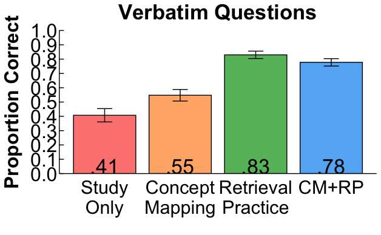

```r
E2data$condition <- factor(E2data$condition, levels = c("Study", "CM", "RP", "CM+RP")) # change order of condition for plotting
# create a table of means for plot annotations
E2verbMeans <- E2data %>%
  group_by(condition) %>%
  summarize(mean = mean(verbProportion)) %>%
  mutate(mean = apa(mean,2,F)) %>%  # false removes leading zero
  droplevels()
# create and store plot
E2.verbPlot <- ggplot(data = E2data, aes(x = condition, y = verbProportion, fill = condition)) +
  # ggplot code to create bar plots
    stat_summary(fun.y = mean, geom = 'bar', position = 'dodge', color = 'black', width = .825) +
    stat_summary(fun.data = mean_se, geom = 'errorbar',
                 position = position_dodge(width = .8), width = .2) +
  # label plot
    ggtitle("Verbatim Questions") + # label plot
    ylab('Proportion Correct')    + # y axis label
    xlab('')                      + # deletes x axis label
    scale_x_discrete(labels = c("Study\nOnly", "Concept\nMapping" ,"Retrieval\nPractice","CM+RP"))+
  # color the bars
    scale_fill_manual(values=c("#FF8682", "#FFB376", "#66bb6a","#64b5f6")) +
  # add means to bars using annotation function, requires dataTable of means and their columnName
    annotations(E2verbMeans, "mean") +
  # y axis limits and tick marks
    coord_cartesian(ylim=c(0, 1.002)) +
    scale_y_continuous(expand = c(0,0), breaks=c(.0,.1,.2,.3,.4,.5,.6,.7,.8, .9, 1)) +
  # theme
    PCLLABtheme
E2.verbPlot # preview plot
```

## 7.2 - Higher order performance

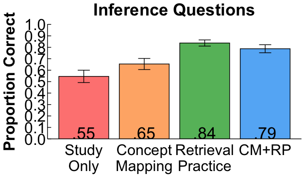

```r
E2data$condition <- factor(E2data$condition, levels = c("Study", "CM", "RP", "CM+RP")) # change order of condition for plotting
# create a table of means for plot annotations
E2higherMeans <- E2data %>%
  group_by(condition) %>%
  summarize(mean = mean(higherProportion)) %>%
  mutate(mean = apa(mean,2,F)) %>%  # false removes leading zero
  droplevels()
# create and store plot
E2.higherPlot <- ggplot(data = E2data, aes(x = condition, y = higherProportion, fill = condition)) +
  # ggplot code to create bar plots
    stat_summary(fun.y = mean, geom = 'bar', position = 'dodge', color = 'black', width = .825) +
    stat_summary(fun.data = mean_se, geom = 'errorbar',
                 position = position_dodge(width = .8), width = .2) +
  # label plot
    ggtitle("Inference Questions") + # label plot
    ylab('Proportion Correct')     + # y axis label
    xlab('')                       + # deletes x axis label
    scale_x_discrete(labels = c("Study\nOnly", "Concept\nMapping" ,"Retrieval\nPractice","CM+RP"))+
  # color the bars
    scale_fill_manual(values=c("#FF8682", "#FFB376", "#66bb6a","#64b5f6")) +
  # add means to bars using annotation function, requires dataTable of means and their columnName
    annotations(E2higherMeans, "mean") +
  # y axis limits and tick marks
    coord_cartesian(ylim=c(0, 1.002)) +
    scale_y_continuous(expand = c(0,0), breaks=c(.0,.1,.2,.3,.4,.5,.6,.7,.8, .9, 1)) +
  # theme
    PCLLABtheme
E2.higherPlot # preview plot
```

## 7.3 - Recall performance

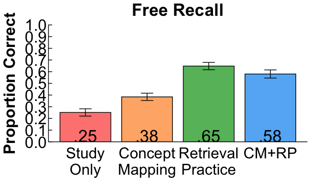

```r
E2data$condition <- factor(E2data$condition, levels = c("Study", "CM", "RP", "CM+RP")) # change order of condition for plotting
# create a table of means for plot annotations
E2r3Means <- E2data %>%
  group_by(condition) %>%
  summarize(mean = mean(r3Proportion)) %>%
  mutate(mean = apa(mean,2,F)) %>%  # false removes leading zero
  droplevels()
# create and store plot
E2.recall3Plot <- ggplot(data = E2data, aes(x = condition, y = r3Proportion, fill = condition)) +
  # ggplot code to create bar plots
    stat_summary(fun.y = mean, geom = 'bar', position = 'dodge', color = 'black', width = .825) +
    stat_summary(fun.data = mean_se, geom = 'errorbar',
                 position = position_dodge(width = .8), width = .2) +
  # label plot
    ggtitle("Free Recall")     + # label plot
    ylab('Proportion Correct') + # y axis label
    xlab('')                   + # deletes x axis label
    scale_x_discrete(labels = c("Study\nOnly", "Concept\nMapping" ,"Retrieval\nPractice","CM+RP")) +
  # color the bars
    scale_fill_manual(values=c("#FF8682", "#FFB376" ,"#66bb6a","#64b5f6")) + # CM color for E2 #
  # add means to bars using annotation function, requires dataTable of means and their columnName
    annotations(E2r3Means, "mean") +
  # y axis limits and tick marks
    coord_cartesian(ylim=c(0, 1.002)) +
    scale_y_continuous(expand = c(0,0), breaks=c(.0,.1,.2,.3,.4,.5,.6,.7,.8, .9, 1)) +
  # theme
    PCLLABtheme
E2.recall3Plot # preview plot
```

# 8 - Exploratory Analyses

## 8.1 - Input-output correspondence

```r
# descriptives
  kable(E2data %>%
    group_by(condition) %>%
    summarize(R1 = apa(mean(propForwardR1, na.rm = T),2),
              R2 = apa(mean(propForwardR2, na.rm = T),2),
              R3 = apa(mean(propForwardR3, na.rm = T),2)
              ), caption = "means") %>%
    kable_styling("condensed", full_width = F, font_size = 14, position = "left")
```

means

| condition | R1 | R2 | R3 |
| --- | --- | --- | --- |
| Study | NaN | NaN | 0.85 |
| CM | NaN | NaN | 0.86 |
| RP | 0.90 | 0.93 | 0.92 |
| CM+RP | 0.87 | 0.91 | 0.91 |

```r
  kable(E2data %>%
    group_by(condition) %>%
    summarize(R1 = apa(sd(propForwardR1, na.rm = T)/sqrt(30),2),
              R2 = apa(sd(propForwardR2, na.rm = T)/sqrt(30),2),
              R3 = apa(sd(propForwardR3, na.rm = T)/sqrt(30),2)
              ), caption = "ses") %>%
    kable_styling("condensed", full_width = F, font_size = 14, position = "left")
```

ses

| condition | R1 | R2 | R3 |
| --- | --- | --- | --- |
| Study | NA | NA | 0.03 |
| CM | NA | NA | 0.02 |
| RP | 0.02 | 0.02 | 0.02 |
| CM+RP | 0.02 | 0.01 | 0.01 |

```r
# R1
  kable(effSize(data = E2data %>% filter(condition == "RP"| condition == "CM+RP") %>%
                  mutate(condition = fct_relevel(condition, c("CM+RP","RP"))) %>% droplevels()
    , analysis = "between"            # within or between design
    , dataFormat = "wide"             # long or wide data
    , outcome = "propForwardR1"       # the outcome variable
    , predictor = "condition"         # the predictor predictor variable
    , n1 = 30                         # sample size for between-group designs
    , n2 = 30                         # sample size for between-group designs
    ), caption = "Proportion of Forward Transitions - Recall 1") %>%
    kable_styling("condensed", full_width = F, font_size = 14, position = "left")
```

Proportion of Forward Transitions - Recall 1

| t | df | p | d | dlow | dhigh | summary |
| --- | --- | --- | --- | --- | --- | --- |
| -1.20 | 58 | 0.234 | -0.31 | -0.82 | 0.20 | t(58) = -1.20, p = 0.234, d = -0.31 [-0.82, 0.20] |

```r
  # R2
  kable(effSize(data = E2data %>% filter(condition == "RP"| condition == "CM+RP")  %>%
                  mutate(condition = fct_relevel(condition, c("CM+RP","RP"))) %>% droplevels()
    , analysis = "between"            # within or between design
    , dataFormat = "wide"             # long or wide data
    , outcome = "propForwardR2"       # the outcome variable
    , predictor = "condition"         # the predictor predictor variable
    , n1 = 30                         # sample size for between-group designs
    , n2 = 30                         # sample size for between-group designs
    ), caption = "Proportion of Forward Transitions - Recall 2") %>%
    kable_styling("condensed", full_width = F, font_size = 14, position = "left")
```

Proportion of Forward Transitions - Recall 2

| t | df | p | d | dlow | dhigh | summary |
| --- | --- | --- | --- | --- | --- | --- |
| -1.06 | 58 | 0.292 | -0.27 | -0.78 | 0.23 | t(58) = -1.06, p = 0.292, d = -0.27 [-0.78, 0.23] |

```r
# R3
  kable(effSize(data = E2data %>% filter(condition == "RP"| condition == "CM+RP") %>%
                  mutate(condition = fct_relevel(condition, c("CM+RP","RP"))) %>% droplevels()
    , analysis = "between"            # within or between design
    , dataFormat = "wide"             # long or wide data
    , outcome = "propForwardR3"       # the outcome variable
    , predictor = "condition"         # the predictor predictor variable
    , n1 = 30                         # sample size for between-group designs
    , n2 = 30                         # sample size for between-group designs
    ), caption = "Proportion of Forward Transitions - Recall 3") %>%
    kable_styling("condensed", full_width = F, font_size = 14, position = "left")
```

Proportion of Forward Transitions - Recall 3

| t | df | p | d | dlow | dhigh | summary |
| --- | --- | --- | --- | --- | --- | --- |
| -0.38 | 58 | 0.705 | -0.10 | -0.60 | 0.41 | t(58) = -0.38, p = 0.705, d = -0.10 [-0.60, 0.41] |

## 8.2 - Conditional recall analysis

```r
# descriptives
  kable(E2data %>%
    filter(condition == "CM+RP" | condition == "RP") %>%
    group_by(condition) %>%
    summarize(CC = apa(mean(CC, na.rm = T),2),
              CN = apa(mean(CN, na.rm = T),2),
              NC = apa(mean(NC, na.rm = T),2),
              NN = apa(mean(NN, na.rm = T),2)
              ), caption = "means") %>%
    kable_styling("condensed", full_width = F, font_size = 14, position = "left")
```

means

| condition | CC | CN | NC | NN |
| --- | --- | --- | --- | --- |
| RP | 0.56 | 0.03 | 0.24 | 0.17 |
| CM+RP | 0.60 | 0.05 | 0.14 | 0.21 |

```r
  kable(E2data %>%
    filter(condition == "CM+RP" | condition == "RP") %>%
    group_by(condition) %>%
    summarize(CC = apa(sd(CC, na.rm = T),2),
              CN = apa(sd(CN, na.rm = T),2),
              NC = apa(sd(NC, na.rm = T),2),
              NN = apa(sd(NN, na.rm = T),2)
              ), caption = "sds") %>%
    kable_styling("condensed", full_width = F, font_size = 14, position = "left")
```

sds

| condition | CC | CN | NC | NN |
| --- | --- | --- | --- | --- |
| RP | 0.22 | 0.03 | 0.12 | 0.16 |
| CM+RP | 0.19 | 0.06 | 0.09 | 0.16 |

```r
# CC
  kable(effSize(data = E2data %>% filter(condition == "RP"| condition == "CM+RP") %>% droplevels()
    , analysis = "between"            # within or between design
    , dataFormat = "wide"             # long or wide data
    , outcome = "CC"                  # the outcome variable
    , predictor = "condition"         # the predictor predictor variable
    , n1 = 30                         # sample size for between-group designs
    , n2 = 30                         # sample size for between-group designs
    ), caption = "CC") %>%
    kable_styling("condensed", full_width = F, font_size = 14, position = "left")
```

CC

| t | df | p | d | dlow | dhigh | summary |
| --- | --- | --- | --- | --- | --- | --- |
| -0.66 | 58 | 0.513 | -0.17 | -0.68 | 0.34 | t(58) = -0.66, p = 0.513, d = -0.17 [-0.68, 0.34] |

```r
  # CN
  kable(effSize(data = E2data %>% filter(condition == "RP"| condition == "CM+RP") %>% droplevels()
    , analysis = "between"            # within or between design
    , dataFormat = "wide"             # long or wide data
    , outcome = "CN"                  # the outcome variable
    , predictor = "condition"         # the predictor predictor variable
    , n1 = 30                         # sample size for between-group designs
    , n2 = 30                         # sample size for between-group designs
    ), caption = "CN") %>%
    kable_styling("condensed", full_width = F, font_size = 14, position = "left")
```

CN

| t | df | p | d | dlow | dhigh | summary |
| --- | --- | --- | --- | --- | --- | --- |
| -2.26 | 58 | 0.027 | -0.58 | -1.10 | -0.07 | t(58) = -2.26, p = 0.027, d = -0.58 [-1.10, -0.07] |

```r
# NC
  kable(effSize(data = E2data %>% filter(condition == "RP"| condition == "CM+RP") %>% droplevels()
    , analysis = "between"            # within or between design
    , dataFormat = "wide"             # long or wide data
    , outcome = "NC"                  # the outcome variable
    , predictor = "condition"         # the predictor predictor variable
    , n1 = 30                         # sample size for between-group designs
    , n2 = 30                         # sample size for between-group designs
    ), caption = "NC") %>%
    kable_styling("condensed", full_width = F, font_size = 14, position = "left")
```

NC

| t | df | p | d | dlow | dhigh | summary |
| --- | --- | --- | --- | --- | --- | --- |
| 3.49 | 58 | 0.001 | 0.90 | 0.37 | 1.43 | t(58) = 3.49, p = 0.001, d = 0.90 [0.37, 1.43] |

```r
# NN
  kable(effSize(data = E2data %>% filter(condition == "RP"| condition == "CM+RP") %>% droplevels()
    , analysis = "between"            # within or between design
    , dataFormat = "wide"             # long or wide data
    , outcome = "NN"                  # the outcome variable
    , predictor = "condition"         # the predictor predictor variable
    , n1 = 30                         # sample size for between-group designs
    , n2 = 30                         # sample size for between-group designs
    ), caption = "NN") %>%
    kable_styling("condensed", full_width = F, font_size = 14, position = "left")
```

NN

| t | df | p | d | dlow | dhigh | summary |
| --- | --- | --- | --- | --- | --- | --- |
| -0.81 | 58 | 0.422 | -0.21 | -0.72 | 0.30 | t(58) = -0.81, p = 0.422, d = -0.21 [-0.72, 0.30] |